# Surface Air Temperature

*By: Jacob Maurer*, [github](https://github.com/JacobMaurer12)

*Date 6-11-2019*

## Introduction

**This webpage is showing the surface air temperature for piControl (present day), and 4 times the CO2 level, which represents the future. The libraries used in the first part of the code below are what store all of the functions that will be used later in the page. Below the libraries is the data used for the presesnt day surface air temperatue for the world.**

```r
library(ggplot2)
library(ncdf4)
library(zoo)
library(RColorBrewer)
library(raster)
library(rasterVis)
library(sf)
library(ncdf.tools)
library(rgdal)
nc_path <- "/Users/jacobmaurer/Documents/College/Geography490/Projects/geog490//"
nc_name <- "PMIP3_tas_piControl_ltm_gcm_CMIP5_CCSM4_OA.nc"
nc_file <- paste(nc_path, nc_name, sep="")
tas_piControl <- raster(nc_file, varname = "tas_ltm")
tas_piControl <- rotate(tas_piControl)
shp_path <- "/Users/jacobmaurer/Documents/College/Geography490/Projects/geog490//"
```

**Like above, this code is similar, but it’s calling a different file. This chunk of code is calling the 4 x CO2 surface air temperature file.**

```r
nc_path <- "/Users/jacobmaurer/Documents/College/Geography490/Projects/geog490//"
nc_name <- "PMIP3_tas_abrupt4xCO2_ltm_gcm_CMIP5_CCSM4_OA.nc"
nc_file <- paste(nc_path, nc_name, sep="")
tas_4xC02 <- raster(nc_file, varname = "tas_ltm")
tas_4xC02 <- rotate(tas_4xC02)
shp_path <- "/Users/jacobmaurer/Documents/College/Geography490/Projects/geog490//"
```

## Country Outlines

**In order to map surface air temperature, you need to show the actual locations, so a country outline map was created in order to shows all of the countries in the world. This was created by adding a world shapefile, seting the geometry of the projection, adding a color, then adding a title.**

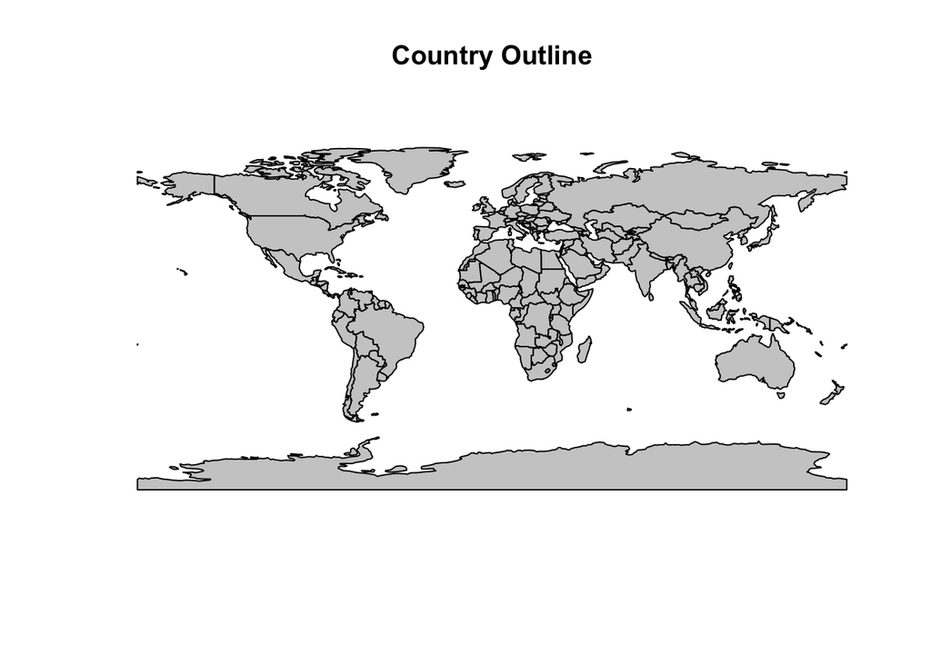

```r
shp_path <- "/Users/jacobmaurer/Documents/College/Geography490/Projects/geog490//"
shp_name <- "ne_110m_admin_0_countries.shp"
shp_file <- paste(shp_path, shp_name, sep="")
world_shp <- read_sf(shp_file)
world_outline <- as(st_geometry(world_shp), Class="Spatial")
plot(world_outline, col="gray80", lwd=1, main = "Country Outline")
```

## Coastal Outline

**While having every coutry can be useful, a coastal outline map was created to allow for plots that look more pleasing. This allows for the plots to be shown without a lot of lines in smaller countries such as Europe. With the coastal outline, it is easy to fill in the area with color to get a better represesntation of the actual surface air temperature.**

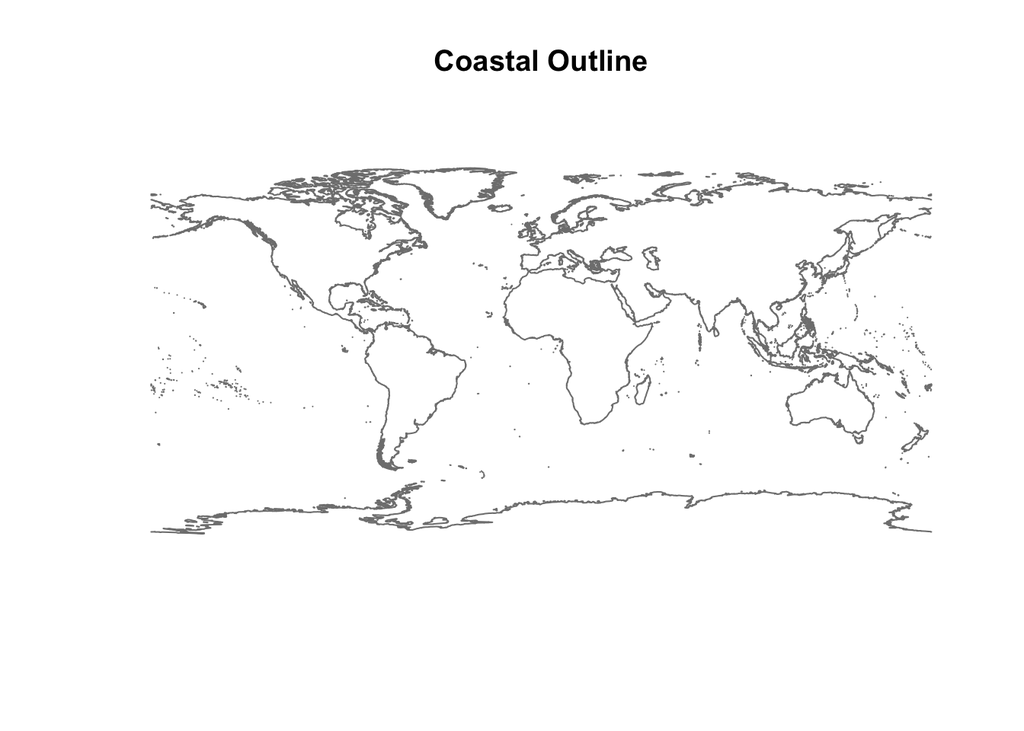

```r
coast_shp_path <- "/Users/jacobmaurer/Documents/College/Geography490/Projects/geog490//"
coast_shp_name <- "ne_10m_coastline.shp"
coast_shp_file <- paste(coast_shp_path, coast_shp_name, sep="")
# read the shapefile
coast_shp <- read_sf(coast_shp_file)
coast_outline <- as(st_geometry(coast_shp), Class="Spatial")
# plot the outline
plot(coast_outline, col="gray50", lwd=1, main = "Coastal Outline")
```

## Present Day Surface Air Temperature

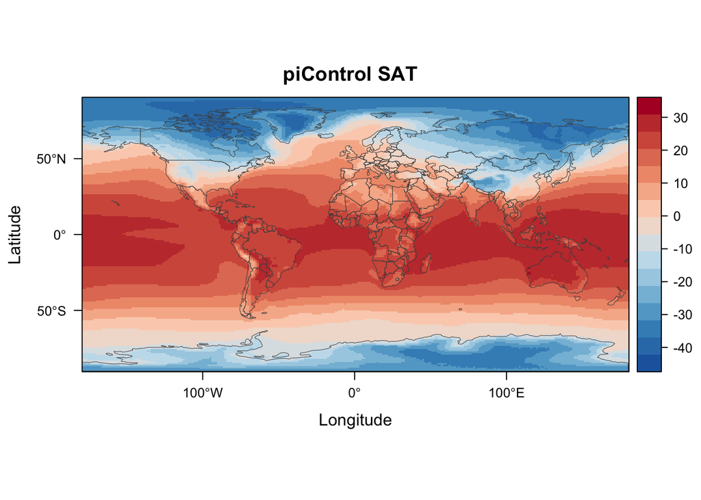

```r
mapTheme <- rasterTheme(region=rev(brewer.pal(8,"RdBu")))
plt <- levelplot(tas_piControl, margin=F, par.settings=mapTheme, main = "piControl SAT")
plt + latticeExtra::layer(sp.lines(world_outline, col="gray30", lwd=0.5))
```

## 4 x CO2 Surface Air Temperature

**Similar to the map above, this map shows the surface air temperatre for the world at 4 times the pre-industrial days (4xCO2). As you can see, the blue is diminishing and the red is spreading, as climatologists expect in the future. The increase in temperature caused the scale on the right to go up 10 more degrees in order to plot the data.**

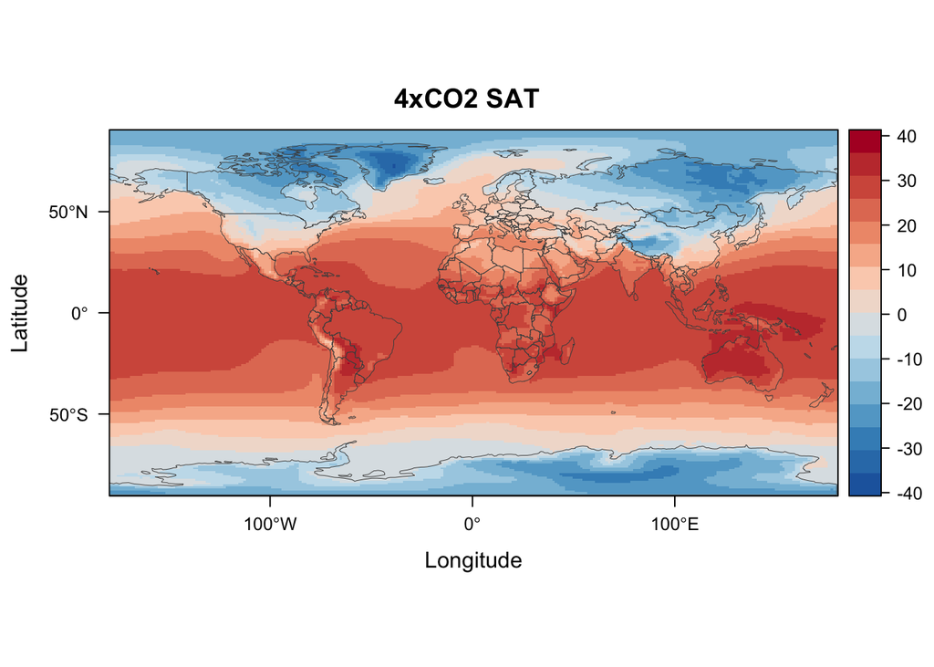

```r
mapTheme <- rasterTheme(region=rev(brewer.pal(8,"RdBu")))
plt <- levelplot(tas_4xC02, margin=F, par.settings=mapTheme, main = "4xCO2 SAT")
plt + latticeExtra::layer(sp.lines(world_outline, col="gray30", lwd=0.5))
```

## Monthly plot of present day SAT

**To get a better representation on how the temperature will change over the months, the code below will plot monthly surface air temperatures for piControl. This is useful for seeing differences in months and getting a sense of how the temperature is changing throughout the year.**

```r
nc_path <- "/Users/jacobmaurer/Documents/College/Geography490/Projects/geog490//"
nc_name <- "PMIP3_tas_piControl_ltm_gcm_CMIP5_CCSM4_OA.nc"
nc_file <- paste(nc_path, nc_name, sep="")
monthly_piControl <- stack(nc_file, varname = "tas_ltm")
monthly_piControl
```

```
## class       : RasterStack
## dimensions  : 192, 288, 55296, 12  (nrow, ncol, ncell, nlayers)
## resolution  : 1.25, 0.9424084  (x, y)
## extent      : -0.625, 359.375, -90.4712, 90.4712  (xmin, xmax, ymin, ymax)
## coord. ref. : +proj=longlat +datum=WGS84 +ellps=WGS84 +towgs84=0,0,0
## names       : X1, X2, X3, X4, X5, X6, X7, X8, X9, X10, X11, X12
## months      : 1, 2, 3, 4, 5, 6, 7, 8, 9, 10, 11, 12
```

```r
monthly_piControl <- rotate(monthly_piControl)
monthly_piControl
```

```
## class       : RasterBrick
## dimensions  : 192, 288, 55296, 12  (nrow, ncol, ncell, nlayers)
## resolution  : 1.25, 0.9424084  (x, y)
## extent      : -179.375, 180.625, -90.4712, 90.4712  (xmin, xmax, ymin, ymax)
## coord. ref. : +proj=longlat +datum=WGS84 +ellps=WGS84 +towgs84=0,0,0
## data source : in memory
## names       :        X1,        X2,        X3,        X4,        X5,        X6,        X7,        X8,        X9,       X10,       X11,       X12
## min values  : -42.28981, -44.77142, -56.21197, -62.16715, -63.55384, -64.55910, -64.49445, -64.96513, -63.70487, -57.91762, -46.84671, -40.10732
## max values  :  30.96722,  30.31149,  32.27741,  32.46327,  36.44992,  38.18685,  40.56625,  39.73972,  34.86125,  31.12742,  31.22544,  31.72402
## months      : 1, 2, 3, 4, 5, 6, 7, 8, 9, 10, 11, 12
```

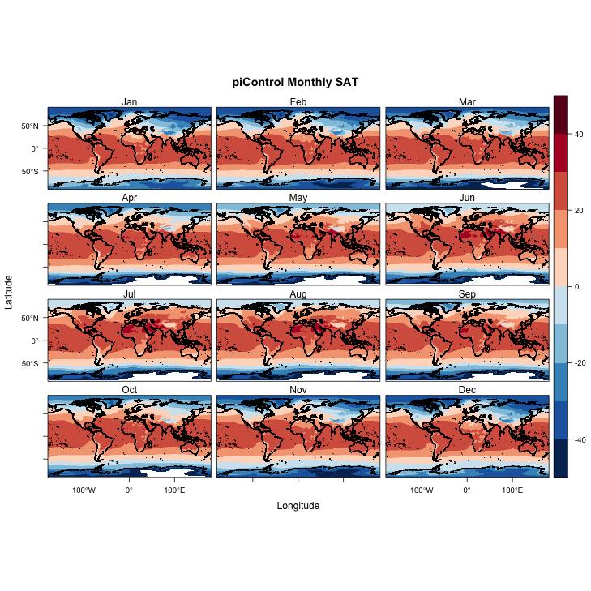

```r
names(monthly_piControl) <- c("Jan","Feb","Mar","Apr","May","Jun","Jul","Aug","Sep","Oct","Nov","Dec")
# too big tp plot to RStudio's Plot window, so send to file:
pngfile <- "monthly_piControl.png"
png(pngfile, width=729, height=729) # open the file
cutpts <- c(-50,-40,-30,-20,-10,0,10,20,30,40,50)
plt <- levelplot(monthly_piControl, main = "piControl Monthly SAT", at=cutpts, cuts=11, pretty=T,
                 col.regions=rev((brewer.pal(10,"RdBu"))))
plt + latticeExtra::layer(sp.lines(coast_outline, col="black", lwd=0.5))
dev.off()
```

## Monthly plot of 4 x C02 SAT

**This is a monthly plot of the 4 x C02 level to compare temperature throughout the year. As with the comparison of the whole year map, these are warmer and have less blue occuring on the map. This map shows a good representation of where the surface air temperature will be affecting first, and from the plots below, you can see an increase in temperature around the Indian Ocean and a small chunk of the Eastern Pacific Ocean. You can also see areas in the South Pole that were white (ice), but are now turning into blue with an increased temperture.This will allow for scientists to see areas that will be affected and allow for them to focus on certain regions.**

```r
nc_path <- "/Users/jacobmaurer/Documents/College/Geography490/Projects/geog490//"
nc_name <- "PMIP3_tas_abrupt4xCO2_ltm_gcm_CMIP5_CCSM4_OA.nc"
nc_file <- paste(nc_path, nc_name, sep="")
monthly_4xC02 <- stack(nc_file, varname = "tas_ltm")
monthly_4xC02
```

```
## class       : RasterStack
## dimensions  : 192, 288, 55296, 12  (nrow, ncol, ncell, nlayers)
## resolution  : 1.25, 0.9424084  (x, y)
## extent      : -0.625, 359.375, -90.4712, 90.4712  (xmin, xmax, ymin, ymax)
## coord. ref. : +proj=longlat +datum=WGS84 +ellps=WGS84 +towgs84=0,0,0
## names       : X1, X2, X3, X4, X5, X6, X7, X8, X9, X10, X11, X12
## months      : 1, 2, 3, 4, 5, 6, 7, 8, 9, 10, 11, 12
```

```r
monthly_4xC02 <- rotate(monthly_4xC02)
monthly_4xC02
```

```
## class       : RasterBrick
## dimensions  : 192, 288, 55296, 12  (nrow, ncol, ncell, nlayers)
## resolution  : 1.25, 0.9424084  (x, y)
## extent      : -179.375, 180.625, -90.4712, 90.4712  (xmin, xmax, ymin, ymax)
## coord. ref. : +proj=longlat +datum=WGS84 +ellps=WGS84 +towgs84=0,0,0
## data source : in memory
## names       :        X1,        X2,        X3,        X4,        X5,        X6,        X7,        X8,        X9,       X10,       X11,       X12
## min values  : -35.68761, -36.37270, -46.74770, -52.05550, -53.65810, -54.71952, -56.27606, -56.58064, -56.67680, -50.19596, -39.19178, -34.45399
## max values  :  36.31553,  35.90699,  37.09993,  37.73124,  41.66225,  44.14027,  46.72800,  46.26369,  41.81416,  36.29920,  35.99542,  36.77942
## months      : 1, 2, 3, 4, 5, 6, 7, 8, 9, 10, 11, 12
```

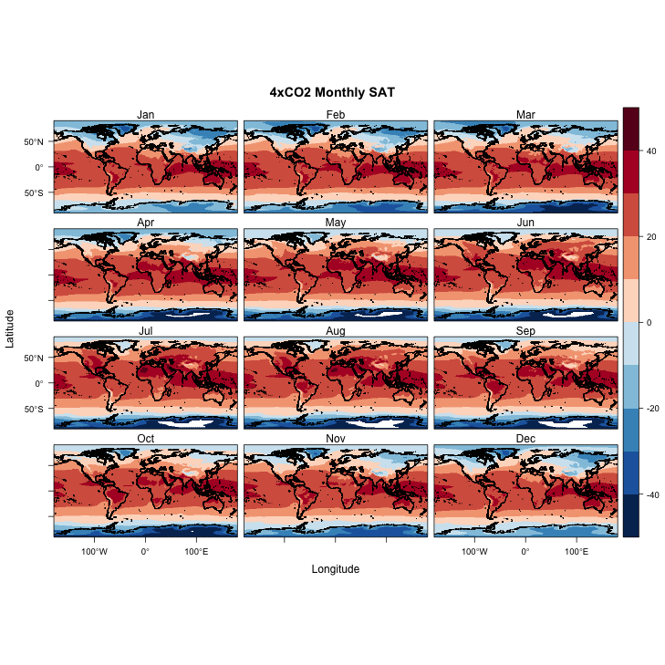

```r
names(monthly_4xC02) <- c("Jan","Feb","Mar","Apr","May","Jun","Jul","Aug","Sep","Oct","Nov","Dec")
# too big tp plot to RStudio's Plot window, so send to file:
pngfile <- "monthly_4xC02.png"
png(pngfile, width=729, height=729) # open the file
cutpts <- c(-50,-40,-30,-20,-10,0,10,20,30,40,50)
plt <- levelplot(monthly_4xC02, main = "4xCO2 Monthly SAT", at=cutpts, cuts=11, pretty=T,
                 col.regions=rev((brewer.pal(10,"RdBu"))))
plt + latticeExtra::layer(sp.lines(coast_outline, col="black", lwd=0.5))
dev.off()
```

## Difference Map

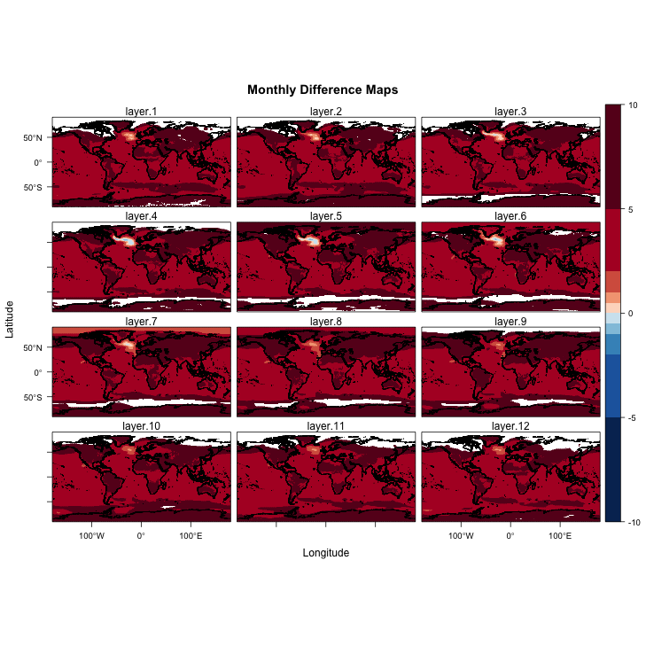

```r
monthly_diff <- monthly_4xC02 - monthly_piControl
pngfile <- "monthly_diff.png"
png(pngfile, width=729, height=729) # open the file
cutpts <- c(-10,-5,-2,-1,-0.5,0,0.5,1,2,5,10)
plt <- levelplot(monthly_diff, main = "Monthly Difference Maps", at=cutpts, cuts=11, pretty=T,
                 col.regions=rev((brewer.pal(10,"RdBu"))))
plt + latticeExtra::layer(sp.lines(coast_outline, col="black", lwd=0.5))
dev.off()
```

### Data Used

1. PMIP3_tas_piControl_ltm_gcm_CMIP5_CCSM4_OA.nc
2. PMIP3_tas_abrupt4xCO2_ltm_gcm_CMIP5_CCSM4_OA.nc
3. ne_110m_admin_0_countries.shp
4. ne_10m_coastline.shp
5. [Ozone Information](https://ozonewatch.gsfc.nasa.gov/facts/hole_SH.html)